# Bellabeat Analysis

Connor McDaniel

2024-09-19

## **Case Study 2: How Can a Wellness Technology Company Play It Smart?**

The goal of this case study is to follow the steps of the data analysis process: Ask, Prepare, Process, Analyze, Share, and Act. This case study is part of the Google Data Analytics Capstone.

#### **Scenario**

I am a junior data analyst on the marketing team at Bellabeat, a high-tech company that manufacturers health-focused products for women. While Bellabeat is already a successful small business, it has the potential to become a significant player in the global smart device market. Urška Sršen, Bellabeat’s cofounder and Chief Creative Officer, believes that analyzing smart device fitness data can unlock new growth opportunities for the company. I have been tasked with focusing on a specific Bellabeat product and analyzing smart device usage data to gain insights into how consumers are using these devices. I will present my analysis to the Bellabeat executive team, along with my high-level recommendations for Bellabeat’s marketing approach.

#### **About the Company**

Urška Sršen and Sando Mur founded Bellabeat, a high-tech company that manufactures health-focused smart products. Sršen used her background as an artist to develop beautifully designed technology that informs and inspires women around the world. Collecting data on activity, sleep, stress, and reproductive health has allowed Bellabeat to empower women with knowledge about their own health and habits. Since it was founded in 2013, Bellabeat has grown rapidly and quickly positioned itself as a tech-driven wellness company for women.

By 2016, Bellabeat had opened offices around the world and launched multiple products. Bellabeat products became available through a growing number of online retailers in addition to their own e-commerce channel on their website ([here](https://bellabeat.com)). The company has invested in traditional advertising media, such as radio, out-of-home billboards, print, and television, but focuses on digital marketing extensively. Bellabeat invests year-round in Google Search, maintaining active Facebook and Instagram pages, and consistently engages consumers on Twitter. Additionally, Bellabeat runs video ads on Youtube and display ads on the Google Display Network to support campaigns around key marketing dates.

Sršen knows that an analysis of Bellabeat’s available consumer data would reveal more opportunities for growth. She has asked the marketing analytics team to focus on a Bellabeat product and analyze smart device usage data in order to gain insight into how people are already using their smart devices. Then, using this information, she would like high-level recommendations for how these trends can inform Bellabeat marketing strategy.

### **Step 1: Ask**

#### **Business Task**

Analyze FitBit Fitness Tracker Data to identify user interaction trends and provide high-level recommendations for Bellabeat’s marketing strategy, focusing on insights applicable to one of its products.

#### **Key Stakeholders**

1. Urška Sršen: Cofounder and Chief Creative Officer
2. Sando Mur: Cofounder and mathematician; key executive team member
3. Bellabeat marketing analytics team

### **Step 2: Prepare**

#### **ROCCC analysis**

Originality: **LOW** – third-party data collected using Amazon Mechanical Turk between 03.12.16-05.12.16.

Comprehensive: **MEDIUM** – dataset contains an arrangement of fields on daily activity, steps, calories, sleep, and weight.

Current: **LOW** – data is from 2016, making it 8 years old.

Cited: **HIGH** – Furberg, Robert; Brinton, Julia; Keating, Michael; Ortiz, Alexa ([here](https://zenodo.org/record/53894#.X9oeh3Uzaao)).

### **Step 3: Process**

I’m using RStudio to clean and transform the data in my analysis. I will also be using RStudio to share my data visualizations.

#### Installing packages

```r
install.packages("tidyverse")
```

```r
install.packages("ggplot2")
install.packages("lubridate")
install.packages("janitor")
install.packages("snakecase")
```

##### Loading packages

```r
library(tidyverse)
```

```r
library(ggplot2)
library(lubridate)
library(janitor)
library(snakecase)
```

##### Importing CSV files

```r
daily_activity <- read.csv("dailyActivity_merged.csv")
daily_sleep <- read.csv("sleepDay_merged.csv")
hourly_calories <- read.csv("hourlyCalories_merged.csv")
hourly_steps <- read.csv("hourlySteps_merged.csv")
hourly_intensities <- read.csv("hourlyIntensities_merged.csv")
```

##### Looking at daily_activity data

```r
head(daily_activity)
```

```
##           Id ActivityDate TotalSteps TotalDistance TrackerDistance
## 1 1503960366    4/12/2016      13162          8.50            8.50
## 2 1503960366    4/13/2016      10735          6.97            6.97
## 3 1503960366    4/14/2016      10460          6.74            6.74
## 4 1503960366    4/15/2016       9762          6.28            6.28
## 5 1503960366    4/16/2016      12669          8.16            8.16
## 6 1503960366    4/17/2016       9705          6.48            6.48
##   LoggedActivitiesDistance VeryActiveDistance ModeratelyActiveDistance
## 1                        0               1.88                     0.55
## 2                        0               1.57                     0.69
## 3                        0               2.44                     0.40
## 4                        0               2.14                     1.26
## 5                        0               2.71                     0.41
## 6                        0               3.19                     0.78
##   LightActiveDistance SedentaryActiveDistance VeryActiveMinutes
## 1                6.06                       0                25
## 2                4.71                       0                21
## 3                3.91                       0                30
## 4                2.83                       0                29
## 5                5.04                       0                36
## 6                2.51                       0                38
##   FairlyActiveMinutes LightlyActiveMinutes SedentaryMinutes Calories
## 1                  13                  328              728     1985
## 2                  19                  217              776     1797
## 3                  11                  181             1218     1776
## 4                  34                  209              726     1745
## 5                  10                  221              773     1863
## 6                  20                  164              539     1728
```

##### Looking at daily_sleep data

```r
head(daily_sleep)
```

```
##           Id              SleepDay TotalSleepRecords TotalMinutesAsleep
## 1 1503960366 4/12/2016 12:00:00 AM                 1                327
## 2 1503960366 4/13/2016 12:00:00 AM                 2                384
## 3 1503960366 4/15/2016 12:00:00 AM                 1                412
## 4 1503960366 4/16/2016 12:00:00 AM                 2                340
## 5 1503960366 4/17/2016 12:00:00 AM                 1                700
## 6 1503960366 4/19/2016 12:00:00 AM                 1                304
##   TotalTimeInBed
## 1            346
## 2            407
## 3            442
## 4            367
## 5            712
## 6            320
```

##### Looking at hourly_calories data

```r
head(hourly_calories)
```

```
##           Id          ActivityHour Calories
## 1 1503960366 4/12/2016 12:00:00 AM       81
## 2 1503960366  4/12/2016 1:00:00 AM       61
## 3 1503960366  4/12/2016 2:00:00 AM       59
## 4 1503960366  4/12/2016 3:00:00 AM       47
## 5 1503960366  4/12/2016 4:00:00 AM       48
## 6 1503960366  4/12/2016 5:00:00 AM       48
```

##### Looking at hourly_steps data

```r
head(hourly_steps)
```

```
##           Id          ActivityHour StepTotal
## 1 1503960366 4/12/2016 12:00:00 AM       373
## 2 1503960366  4/12/2016 1:00:00 AM       160
## 3 1503960366  4/12/2016 2:00:00 AM       151
## 4 1503960366  4/12/2016 3:00:00 AM         0
## 5 1503960366  4/12/2016 4:00:00 AM         0
## 6 1503960366  4/12/2016 5:00:00 AM         0
```

##### Looking at hourly_intensities data

```r
head(hourly_intensities)
```

```
##           Id          ActivityHour TotalIntensity AverageIntensity
## 1 1503960366 4/12/2016 12:00:00 AM             20         0.333333
## 2 1503960366  4/12/2016 1:00:00 AM              8         0.133333
## 3 1503960366  4/12/2016 2:00:00 AM              7         0.116667
## 4 1503960366  4/12/2016 3:00:00 AM              0         0.000000
## 5 1503960366  4/12/2016 4:00:00 AM              0         0.000000
## 6 1503960366  4/12/2016 5:00:00 AM              0         0.000000
```

While reviewing the column names, I decided to merge hourly_calories, hourly_intensities, and hourly_steps into a single dataset using the “Id” and “ActivityHour” columns.

##### Merging hourly_calories, hourly_steps, and hourly_intensities into a single data frame

```r
hourly_activity <- merge(hourly_calories,hourly_steps,by=c("Id","ActivityHour"))
hourly_activity <- merge(hourly_activity,hourly_intensities,by=c("Id","ActivityHour"))
```

##### Checking for missing values

```r
sum(is.na(daily_activity))
```

```
## [1] 0
```

```r
sum(is.na(daily_sleep))
```

```
## [1] 0
```

```r
sum(is.na(hourly_activity))
```

```
## [1] 0
```

There are no missing values.

##### Checking for duplicates

```r
sum(duplicated(daily_activity))
```

```
## [1] 0
```

```r
sum(duplicated(daily_sleep))
```

```
## [1] 3
```

```r
sum(duplicated(hourly_activity))
```

```
## [1] 0
```

There are 3 duplicates found in daily_sleep.

##### Cleaning the duplicates from daily_sleep

```r
daily_sleep <- unique(daily_sleep)
sum(duplicated(daily_sleep))
```

```
## [1] 0
```

##### Cleaning the column names for better readability

```r
clean_names(daily_activity)
clean_names(daily_sleep)
clean_names(hourly_activity)
```

```r
names(daily_activity) <- to_snake_case(names(daily_activity))
names(daily_sleep) <- to_snake_case(names(daily_sleep))
names(hourly_activity) <- to_snake_case(names(hourly_activity))
```

##### Converting date & time format

```r
daily_activity$activity_date <- mdy(daily_activity$activity_date)
daily_sleep$sleep_day <- mdy_hms(daily_sleep$sleep_day)
hourly_activity$activity_hour <- mdy_hms(hourly_activity$activity_hour)
```

##### Renaming ‘activity_date’ and ‘sleep_day to ‘date’

```r
daily_activity <- daily_activity %>%
  rename(date = activity_date)
```

```r
daily_sleep <- daily_sleep %>%
  rename(date = sleep_day)
```

##### Adding a ‘week_day’ column to show days of the week

```r
daily_activity <- daily_activity %>%
  mutate(week_day = weekdays(as.Date.factor(date)))
```

##### Adding a ‘total_active_minutes’ column

```r
daily_activity$total_active_minutes = (daily_activity$very_active_minutes + daily_activity$fairly_active_minutes + daily_activity$lightly_active_minutes)
```

##### Checking the number of unique participants

```r
n_distinct(daily_activity$id)
```

```
## [1] 33
```

```r
n_distinct(daily_sleep$id)
```

```
## [1] 24
```

```r
n_distinct(hourly_activity$id)
```

```
## [1] 33
```

##### Checking the number of observations

```r
nrow(daily_activity)
```

```
## [1] 940
```

```r
nrow(daily_sleep)
```

```
## [1] 410
```

```r
nrow(hourly_activity)
```

```
## [1] 22099
```

```r
combined_merge <- merge(daily_activity, daily_sleep)
n_distinct(combined_merge$id)
```

```
## [1] 24
```

##### Merging average sleep and average steps into a new data frame ‘sleep_vs_steps’

```r
avg_sleeping_mins <- combined_merge %>%
  group_by(id) %>%
  summarize(avg_sleeping_mins = mean(total_minutes_asleep))

avg_total_steps <- combined_merge %>%
  group_by(id) %>%
  summarize(avg_total_steps = mean(total_steps))

sleep_vs_steps <- merge(avg_sleeping_mins, avg_total_steps)
```

##### Looking at summary statistics

```r
combined_merge %>%
  select(total_steps,
         calories,
         total_minutes_asleep,
         total_time_in_bed) %>%
  summary()
```

```
##   total_steps       calories    total_minutes_asleep total_time_in_bed
##  Min.   :   17   Min.   : 257   Min.   : 58.0        Min.   : 61.0
##  1st Qu.: 5189   1st Qu.:1841   1st Qu.:361.0        1st Qu.:403.8
##  Median : 8913   Median :2207   Median :432.5        Median :463.0
##  Mean   : 8515   Mean   :2389   Mean   :419.2        Mean   :458.5
##  3rd Qu.:11370   3rd Qu.:2920   3rd Qu.:490.0        3rd Qu.:526.0
##  Max.   :22770   Max.   :4900   Max.   :796.0        Max.   :961.0
```

```r
hourly_activity %>%
  select(activity_hour,
         step_total,
         calories,
         total_intensity) %>%
  summary()
```

```
##  activity_hour                      step_total         calories
##  Min.   :2016-04-12 00:00:00.00   Min.   :    0.0   Min.   : 42.00
##  1st Qu.:2016-04-19 01:00:00.00   1st Qu.:    0.0   1st Qu.: 63.00
##  Median :2016-04-26 06:00:00.00   Median :   40.0   Median : 83.00
##  Mean   :2016-04-26 11:46:42.58   Mean   :  320.2   Mean   : 97.39
##  3rd Qu.:2016-05-03 19:00:00.00   3rd Qu.:  357.0   3rd Qu.:108.00
##  Max.   :2016-05-12 15:00:00.00   Max.   :10554.0   Max.   :948.00
##  total_intensity
##  Min.   :  0.00
##  1st Qu.:  0.00
##  Median :  3.00
##  Mean   : 12.04
##  3rd Qu.: 16.00
##  Max.   :180.00
```

```r
sleep_vs_steps %>%
  select(avg_sleeping_mins,
         avg_total_steps) %>%
  summary()
```

```
##  avg_sleeping_mins avg_total_steps
##  Min.   : 61.0     Min.   : 1490
##  1st Qu.:336.3     1st Qu.: 5106
##  Median :417.2     Median : 8336
##  Mean   :377.4     Mean   : 7880
##  3rd Qu.:449.3     3rd Qu.: 9394
##  Max.   :652.0     Max.   :19079
```

##### According to the U.S. Department of Health and Human Services, most adults need 7 or more hours of good-quality sleep each night. I am filtering participants that get less than 7 hours of sleep and less than the group average in steps taken daily.

```r
sleep_vs_steps %>%
  filter(avg_sleeping_mins <= 420,
         avg_total_steps <= 7880)
```

```
##           id avg_sleeping_mins avg_total_steps
## 1 1927972279          417.0000        1490.000
## 2 2320127002           61.0000        5079.000
## 3 4020332650          349.3750        6596.750
## 4 4445114986          385.1786        4756.179
## 5 6775888955          349.6667        3499.000
## 6 7007744171           68.5000        5115.500
```

### **Step 4 & 5: Analyze/Share**

#### Figure 1 - What’s the relationship between steps taken in a day and sedentary minutes?

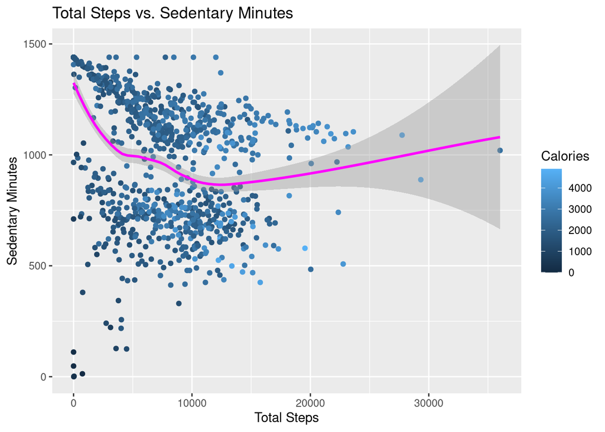

```r
ggplot(data = daily_activity, aes(x = total_steps, y = sedentary_minutes, color = calories)) +
  geom_point() +
  geom_smooth(method = "loess", color = "magenta") +
  labs(x = "Total Steps", y = "Sedentary Minutes", title = "Total Steps vs. Sedentary Minutes") +
  scale_color_continuous("Calories")
```

I was surprised to notice that after reaching 15,000 steps, the relationship between total steps and sedentary minutes begins to show a slight positive trend. This comparison reveals that even when users achieve high step counts, they may still experience significant periods of sedentary behavior throughout the day. This highlights a potential gap in activity patterns that Bellabeat can address.

#### Figure 2 – What’s the relationship between minutes asleep and time in bed?

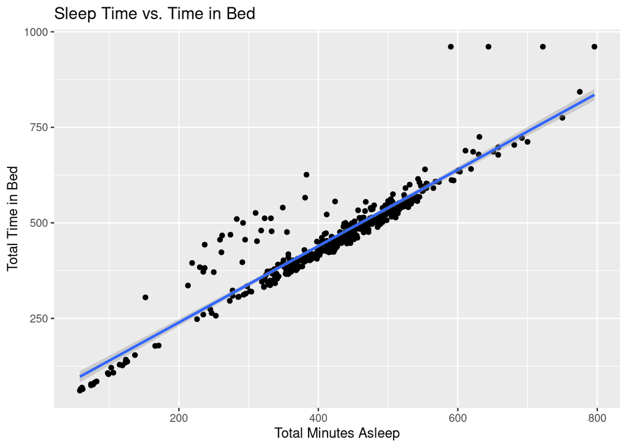

```r
ggplot(data = combined_merge, aes(x = total_minutes_asleep, y = total_time_in_bed)) +
  geom_point() +
  stat_smooth(method = lm) +
  labs(x = "Total Minutes Asleep", y = "Total Time in Bed", title = "Sleep Time vs. Time in Bed")
```

We observe a strong positive correlation between total minutes asleep and total time in bed. However, the plot shows several outliers, particularly in the middle and upper ranges. These outliers represent participants who spent significant time in bed but had minimal sleep.

#### Figure 3 – Does more sleep on average lead to more total steps on average?

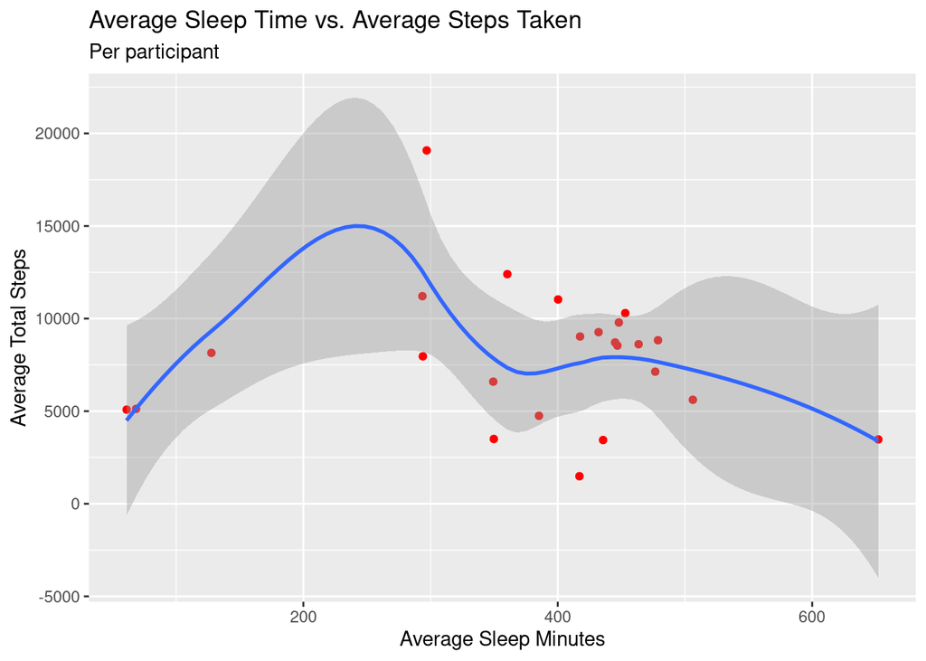

```r
ggplot(data = sleep_vs_steps, mapping = aes(x = avg_sleeping_mins, y = avg_total_steps)) +
  geom_jitter(color = "red") +
  geom_smooth() +
  labs(title = "Average Sleep Time vs. Average Steps Taken", subtitle = "Per participant", x = "Average Sleep Minutes", y = "Average Total Steps")
```

```r
cor(sleep_vs_steps$avg_sleeping_mins, sleep_vs_steps$avg_total_steps)
```

```
## [1] -0.06633235
```

The correlation between average sleep minutes and average total steps is approximately -0.07. This indicates a very weak negative relationship, suggesting that there is little to no significant association between the amount of sleep and the number of steps taken.

#### Figure 4 - On which days of the week are participants most likely to burn the most calories?

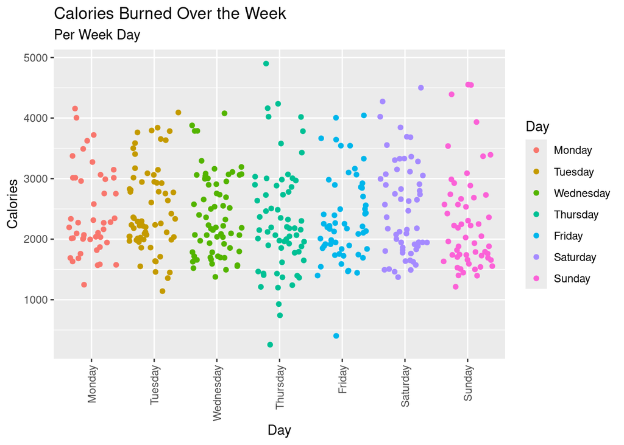

```r
week_days <- factor(combined_merge$week_day, levels = c("Monday", "Tuesday", "Wednesday", "Thursday", "Friday", "Saturday", "Sunday"))

ggplot(data = combined_merge, mapping = aes(x = week_days, y = calories, color = week_days)) +
  geom_point(position = "jitter", stat = "identity") +
  labs(title = "Calories Burned Over the Week", subtitle = "Per Week Day") +
  scale_x_discrete("Day", guide = guide_axis(angle = 90)) +
  scale_color_discrete("Day") +
  ylab("Calories")
```

#### Figure 5 - Does getting more sleep result in a more active day? We will compare total minutes of sleep with total steps taken to examine how these two variables vary over the course of the week.

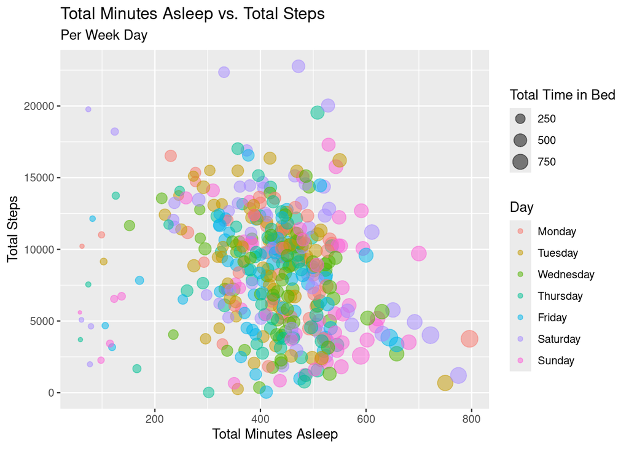

```r
ggplot(data = combined_merge, mapping = aes(x = total_minutes_asleep, y = total_steps, color = week_days, size = total_time_in_bed)) +
  geom_point(alpha = 0.5) +
  scale_size("Total Time in Bed") +
  scale_color_discrete("Day") +
  theme(legend.position = "right") +
  labs(title = "Total Minutes Asleep vs. Total Steps",
       subtitle = "Per Week Day",
       x = "Total Minutes Asleep", y = "Total Steps")
```

```r
cor(combined_merge$total_minutes_asleep, combined_merge$total_steps)
```

```
## [1] -0.1903439
```

The correlation between total minutes of sleep and total steps is approximately -0.19. This negative correlation indicates a weak inverse relationship between the two variables. In other words, as total minutes of sleep increases slightly, total steps tend to decrease slightly, but the relationship is not strong.

#### Figure 6 – On which days of the week are participants getting the most sleep?

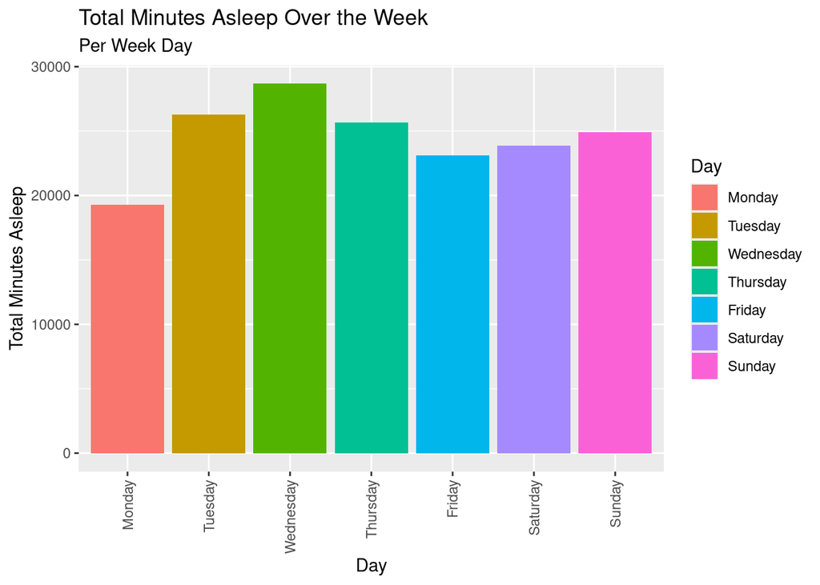

```r
ggplot(data = combined_merge, mapping = aes(x = week_days, y = total_minutes_asleep, fill = week_days)) +
  geom_bar(stat = "identity") +
  labs(title = "Total Minutes Asleep Over the Week", subtitle = "Per Week Day", x = "Day", y = "Total Minutes Asleep") +
  scale_x_discrete(guide = guide_axis(angle = 90)) +
  scale_fill_discrete("Day")
```

The bar chart shows that Wednesday has the highest total sleep minutes, while Monday records the lowest amount of sleep. Monday’s reduced sleep might be due to the exhaustion from transitioning back into the week.

#### Figure 7 - What’s the relationship between steps taken and calories burned?

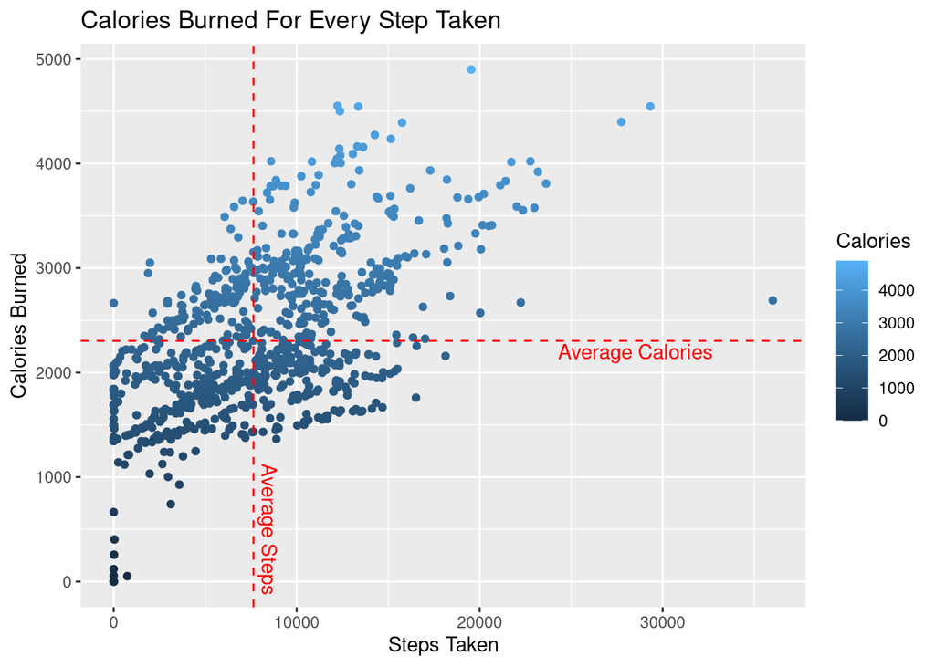

```r
ggplot(data = daily_activity) +
  geom_point(mapping = aes(x = total_steps, y = calories, color = calories)) +
  geom_vline(xintercept = mean(daily_activity$total_steps), linetype = "dashed", color = "red") +  # Vertical line at mean total steps
  geom_hline(yintercept = mean(daily_activity$calories), linetype = "dashed", color = "red") +  # Horizontal line at mean sedentary minutes
  annotate("text", x = 8500, y = 500, label = "Average Steps", color = "red", srt = -90) +
  annotate("text", x = 28500, y = 2200, label = "Average Calories", color = "red") +
  labs(title = "Calories Burned For Every Step Taken", x = "Steps Taken", y = "Calories Burned") +
  scale_color_continuous("Calories")
```

We see a positive correlation between calories burned and steps taken, with a few outliers at the top and bottom. The figure shows the more calories burned, the more step numbers rise.

#### Figure 8 - At what hours are participants most active?

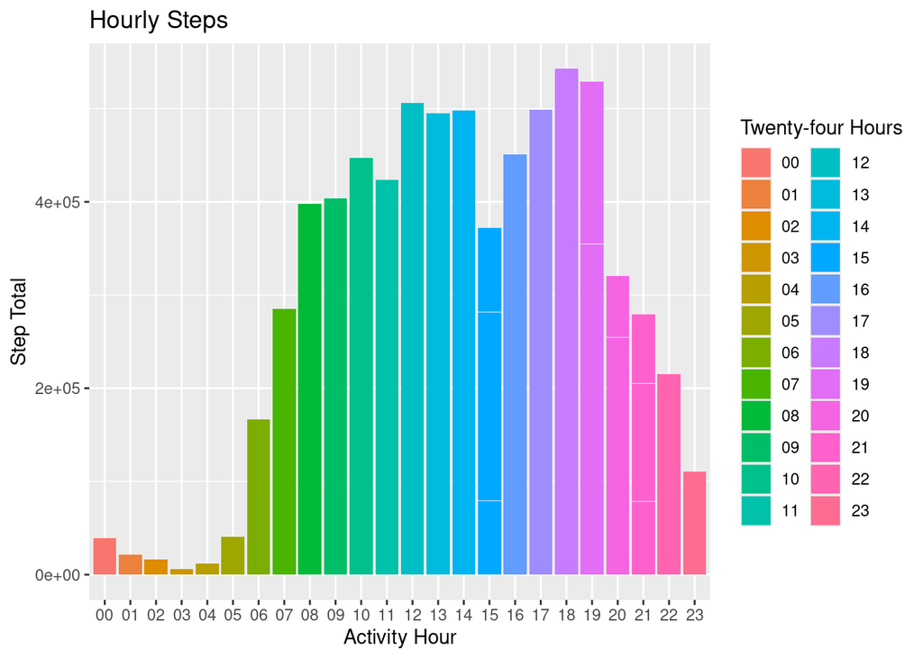

```r
twenty_four_hours <- format(as.POSIXct(hourly_activity$activity_hour), format = "%H")

ggplot(data = hourly_activity, aes(x = twenty_four_hours, y = step_total, fill = twenty_four_hours)) +
  geom_bar(stat = "identity") +
  scale_fill_discrete("Twenty-four Hours") +
  labs(title = "Hourly Steps", x = "Activity Hour", y = "Step Total")
```

Participants appear to be most active between 6-7 PM each day, while their activity levels drop significantly from 8 PM to 5 AM. There is a notable decrease in activity around 3 PM, revealing a clear window of opportunity to engage users with targeted reminders.

### **Step 6: Act**

#### **Recommendations**

##### **Leverage Low-Activity Periods for Engagement:**

Based on the drop in activity around 3 PM, Bellabeat can implement push notifications encouraging users to take short walks or stretch breaks. These nudges can address the afternoon slump, helping users increase their step counts and overall daily activity. This data-driven approach could enhance user engagement and support more active habits during low-activity periods.

##### **Enhance Marketing Efforts During Peak Demand Time:**

Focus on promoting annual memberships at the start of the year when many are setting health-related New Year’s resolutions. Launch special campaigns and promotions in the summer months to encourage increased physical activity since outdoor activities are more popular. This approach aims to increase membership sign-ups and boost user engagement during peak periods of interest in health and fitness.

##### **Enhance User Sleep with Tailored Evening Routines:**

While there isn’t a strong correlation between increased sleep and higher step counts, consistent sleep schedules can still positively impact user well-being. Bellabeat could support users by providing personalized bedtime reminders, helping them maintain healthy sleep routines that optimize energy levels and overall wellness. Prioritizing a balanced evening routine promotes overall physical and mental health.

##### **Promote Active Lifestyles:**

Given the prevalence of sedentary habits, Bellabeat should launch educational campaigns highlighting the benefits of regular physical activity for overall health. Partnering with prominent gym chains can also enhance visibility and provide users with additional support and motivation. By combining informative content with strategic partnerships, Bellabeat can encourage more active habits and help users build confidence in their fitness journey.